# HW4

Yash Gangrade

April 8, 2018

## Question 1

### a) Running the code with just ising prior

Here, we just use the ising prior to get the images. We are also generating binary random images using the indigenous rand_generator function written. We are testing with different values of alpha, beta, and sigma. Different category of images are shown in the results. We are using 50 iterations to generate random binary images.

Through this experiment, we can observe the effects of alpha and beta over the image. We know that negative values of alpha favors more -1 (Black) pixels and similarly positive values of alpha favors more +1 (White) pixels. And, high beta favours bigger blobs of white or black pixels. This phenomenon can be observed in the test images of ques1 a.

### b) Computing mean posterior images.

The clean images are shown in the results below. We used the following values.

Noisy Message -> alpha = 0, beta = 2.2, sigma^2 = 1.4, iterations = 100, burn-in = 20 Noisy Yinyang -> alpha = 0, beta = 5.5, sigma^2 = 2.5, iterations = 100, burn-in = 20

### c) Final estimate of variance.

Here, we compute the variance estimate at each iteration. The final estimate that we get for both the images matches closely to the chosen variance values in b part. For noisy markov image, we get final estimate of variance as ~1.45 and for the noisy yinyang image, we get final estimate of variance as ~2.54.

## CODE and RESULTS

```r
source("Markov.r", echo = TRUE, keep.source = TRUE, max.deparse.length=10000)
```

```
##
## > require(png)
```

```
##
## > library(magick)
```

```
## Linking to ImageMagick 6.9.9.14
## Enabled features: cairo, freetype, fftw, ghostscript, lcms, pango, rsvg, webp
## Disabled features: fontconfig, x11
```

```
##
## > read_image = function(file){
## +   x = readPNG(file, native = FALSE)
## +   x = x*20 - 10
## +
## +   t(x)[,nrow(x):1]
## + }
##
## > display_image = function(x, col=gray(seq(0,1,1/256)))
## + {
## +   w = dim(x)[1]
## +   h = dim(x)[2]
## +   par(mai = c(0,0,0,0))
## +   image(x, asp=h/w, col=col)
## + }
##
## > rand_generator = function()
## + {
## +   rand = runif(1)
## +   if(rand < 0.5)
## +     return (1)
## +   else
## +     return (-1)
## + }
##
## > checkerboard = function(row, col){
## +   check = matrix(0, row, col)
## +   for(i in 1:row){
## +     for(j in 1:col){
## +       if(check[i,j] == ((i+j) %% 2)){
## +         check[i,j] = 0
## +       }
## +       else{
## +         check[i,j] = 1
## +       }
## +     }
## +   }
## +   return(check)
## + }
##
```

[output cut: 234 more lines]

```
## > #       #sample_sig[num,] = sig
## > #       sig = new_var/(num_row * num_col)
## > #     }
## > #     img = img3
## > #   }
## > #   #print(sum(sample_sig)/iterations)
## > #   cat("The sigma is ", sig)
## > #   return(img2)
## > # }
## >
## >
## >
## >
## >
## >
```

```r
img1 = read_image("noisy-message.png")
img2 = read_image("noisy-yinyang.png")

#display_image(img1)
#display_image(img2)

num_col = dim(img1)[2]
num_row = dim(img1)[1]

binary_img = matrix(0, num_row, num_col)
binary_img = apply(binary_img, 1:2, function(x) rand_generator());

#checkerboard(num_row, num_col)
#display_image(binary_img)

## Question 1.1
cat("Trying to run for different alphas and betas \n")
```

```
## Trying to run for different alphas and betas
```

```r
cat("Negative Alpha and Positive High Beta \n")
```

```
## Negative Alpha and Positive High Beta
```

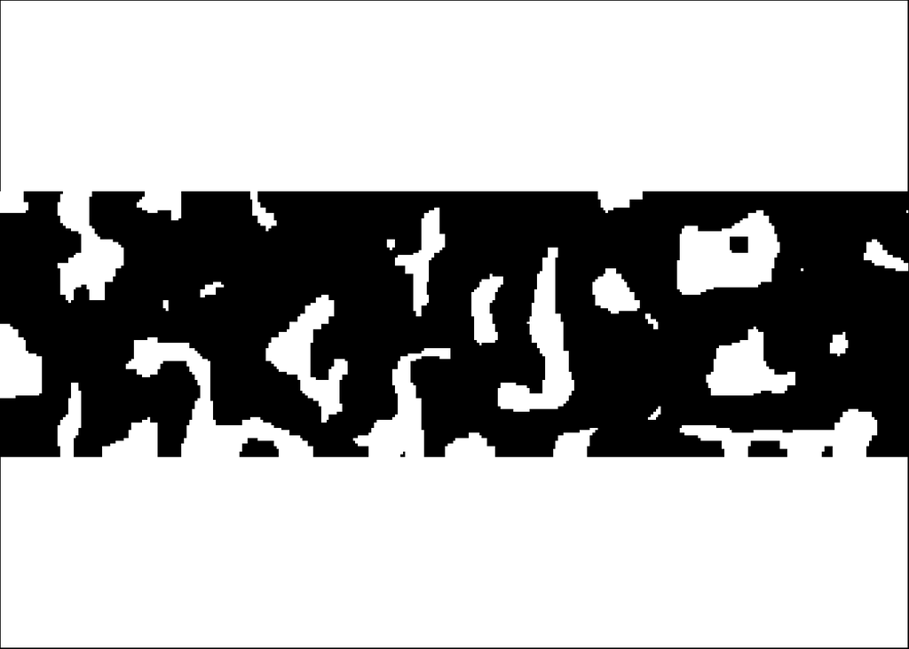

```r
resultant_img = gibbs_sampling_prior(binary_img, -0.1, 3, 1.5, 50, 5);
display_image(resultant_img)
```

```r
# #
cat("Negative Alpha and Low Beta \n")
```

```
## Negative Alpha and Low Beta
```

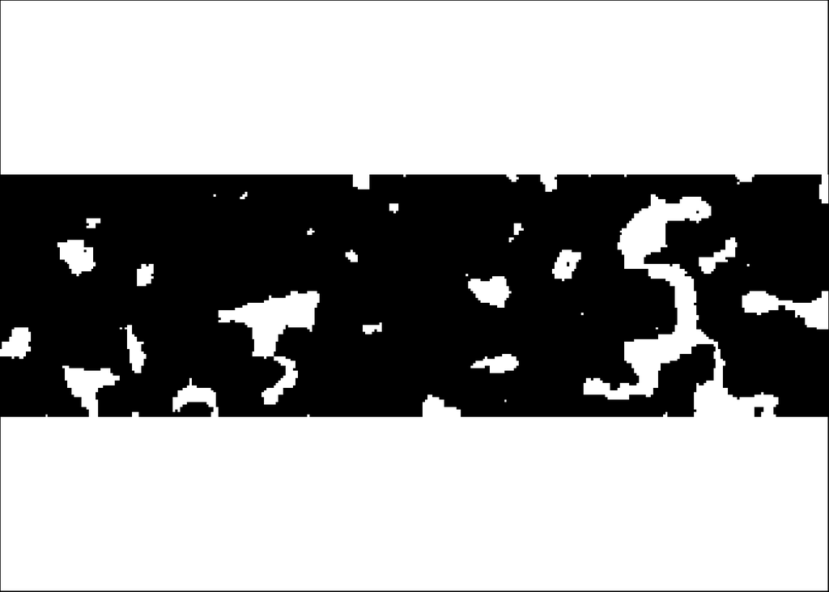

```r
resultant_img = gibbs_sampling_prior(binary_img, -0.1, 1, 1.5, 50, 5);
display_image(resultant_img)
```

```r
# #
cat("Positive Alpha and Positive High Beta \n")
```

```
## Positive Alpha and Positive High Beta
```

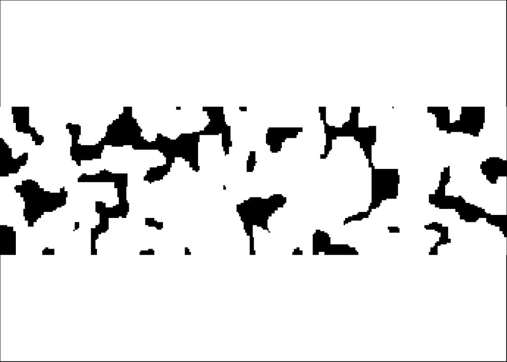

```r
resultant_img = gibbs_sampling_prior(binary_img, 0.1, 3, 1.5, 50, 5);
display_image(resultant_img)
```

```r
# #
cat("Positive Alpha and Low Beta \n")
```

```
## Positive Alpha and Low Beta
```

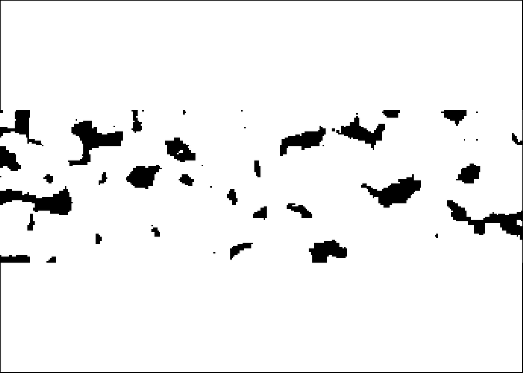

```r
resultant_img = gibbs_sampling_prior(binary_img, 0.1, 1, 1.5, 50, 5);
display_image(resultant_img)
```

```r
#
# ## Question 1.2
cat("Running for the Markov Noisy Image \n")
```

```
## Running for the Markov Noisy Image
```

```r
#
cat("Here's the noisy image i.e. noisy-message.png \n")
```

```
## Here's the noisy image i.e. noisy-message.png
```

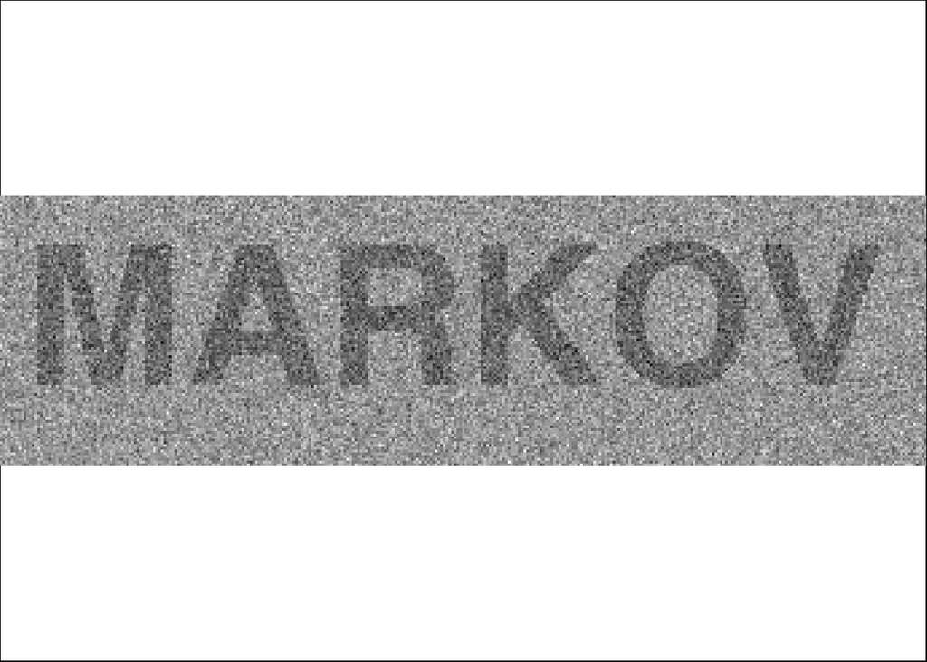

```r
display_image(img1)
```

```r
#
cat("We used alpha = 0, beta = 2.2, sigma = 1.4 with 100 iterations and 20 burn-in samples. The clean image is shown below \n")
```

```
## We used alpha = 0, beta = 2.2, sigma = 1.4 with 100 iterations and 20 burn-in samples. The clean image is shown below
```

[figure not shown]

```r
resultant_img = gibbs_sampling_prior_posterior(img1, 0, 2.2, 1.4, 100, 20);
display_image(resultant_img)
```

```r
cat("Running for the Noisy Yinyang Image \n")
```

```
## Running for the Noisy Yinyang Image
```

```r
#
cat("Here's the noisy image i.e. noisy-yinyang.png \n")
```

```
## Here's the noisy image i.e. noisy-yinyang.png
```